# Live births in Scotland 2022

Health boards ranking

Inmaculada Ruiz-Morales

31-08-2024

```r
# I load my favorite packages (I don´t always use all of them but I keep all in
# my template).
library(tidyverse)
library(janitor)
library(lubridate)
library(kableExtra)
library(formatR)
library(scales)
library(sp)
library(sf)
library(gridExtra)
library(latticeExtra)
library(cowplot)
```

# Data used

To perfom this analysis, two datasets has been retrieved from [The Scottish Health and Social Care Open Data platform](https://www.opendata.nhs.scot/) for their analysis. And one from the [Spatial Data Metadata Portal](https://spatialdata.gov.scot/geonetwork/srv/eng/catalog.search#/home), Scotland’s catalogue of spatial data.

Reading the data and cleaning variable names:

```r
#read in .csv files with the data  and clea_names
births <- read_csv("https://www.opendata.nhs.scot/dataset/df10dbd4-81b3-4bfa-83ac-b14a5ec62296/resource/d534ae02-7890-4fbc-8cc7-f223d53fb11b/download/10.3_birthsbyhospital.csv") %>%
  clean_names() %>%
  separate(financial_year, into = c("year", NA), sep = "/")

hospitals <- read_csv("https://www.opendata.nhs.scot/dataset/cbd1802e-0e04-4282-88eb-d7bdcfb120f0/resource/c698f450-eeed-41a0-88f7-c1e40a568acc/download/current-hospital_flagged20211216.csv") %>%
  clean_names()

#read in .shp file
## you need to download all the files in your computer and change the path in the code
path = "D:/SpatiaDataFiles/SG_NHS_HealthBoards_2019.shp"
hb_spatial <- st_read(path)
```

We can see that the category ‘outcome’ could be ‘Live’, ‘Still’ or ‘Unknown’. We are going to represent live births

```r
head(births)
```

```
## # A tibble: 6 × 5
##   year  ca     hospital outcome smr02births
##   <chr> <chr>  <chr>    <chr>         <dbl>
## 1 1997  RA2704 A103H    Live             11
## 2 1997  RA2704 A103H    Still             1
## 3 1997  RA2704 B120H    Live             39
## 4 1997  RA2704 C206H    Live              1
## 5 1997  RA2704 C313H    Live              2
## 6 1997  RA2704 C418H    Live              2
```

```r
table(births$outcome)
```

```
##
##    Live   Still Unknown
##    7440    1329      65
```

## Total live births in Scotland in the financial year 2022-23

```r
births %>%
  filter(year==2022 & outcome=="Live") %>%
  summarize(new_babies_2022 = sum(smr02births))
```

```
## # A tibble: 1 × 1
##   new_babies_2022
##             <dbl>
## 1           45061
```

## Babies born at home in 2022

```r
#number of babies born at home
births %>%
  filter(year==2022 & outcome=="Live" & hospital=="D201N") %>%
  summarize("Babies born at home in 2022"= sum(smr02births))
```

```
## # A tibble: 1 × 1
##   `Babies born at home in 2022`
##                           <dbl>
## 1                           209
```

# Evolution of total number of live births a long time since 1997 to 2022

```r
baby_year <- births %>% filter (outcome=="Live") %>%
  group_by(year) %>%
  summarise(number_of_babies = sum(smr02births))
kable(baby_year)
```

| year | number_of_babies |
| --- | --- |
| 1997 | 58282 |
| 1998 | 56471 |
| 1999 | 54073 |
| 2000 | 52498 |
| 2001 | 50799 |
| 2002 | 50977 |
| 2003 | 52585 |
| 2004 | 53366 |
| 2005 | 52971 |
| 2006 | 54982 |
| 2007 | 57983 |
| 2008 | 58525 |
| 2009 | 58066 |
| 2010 | 57696 |
| 2011 | 57952 |
| 2012 | 56406 |
| 2013 | 55274 |
| 2014 | 55365 |
| 2015 | 54571 |
| 2016 | 53644 |
| 2017 | 51938 |
| 2018 | 50556 |
| 2019 | 48642 |
| 2020 | 46158 |
| 2021 | 47518 |
| 2022 | 45061 |

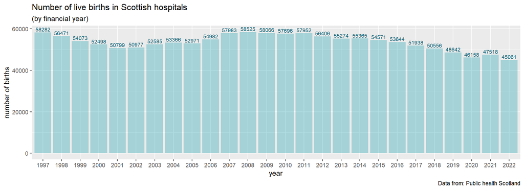

```r
ggplot(baby_year, aes(year, number_of_babies)) + geom_col(fill="#0097a7", alpha=0.3)+
  geom_text(aes(label = number_of_babies), vjust=-0.3, size =2.8, color='#005B70') +
  labs(
    title = "Number of live births in Scottish hospitals",
    subtitle = "(by financial year)",
    caption="Data from: Public health Scotland") +
  ylab("number of births")
```

# Evolution of still births outcomes since 1997 to 2022

```r
still_year <- births %>%
  filter (outcome=="Still") %>%
  group_by(year) %>%
  summarise(still_births = sum(smr02births))
kable(still_year)
```

| year | still_births |
| --- | --- |
| 1997 | 307 |
| 1998 | 318 |
| 1999 | 240 |
| 2000 | 286 |
| 2001 | 254 |
| 2002 | 245 |
| 2003 | 322 |
| 2004 | 256 |
| 2005 | 269 |
| 2006 | 295 |
| 2007 | 293 |
| 2008 | 298 |
| 2009 | 297 |
| 2010 | 277 |
| 2011 | 260 |
| 2012 | 231 |
| 2013 | 235 |
| 2014 | 200 |
| 2015 | 199 |
| 2016 | 216 |
| 2017 | 214 |
| 2018 | 173 |
| 2019 | 155 |
| 2020 | 190 |
| 2021 | 175 |
| 2022 | 157 |

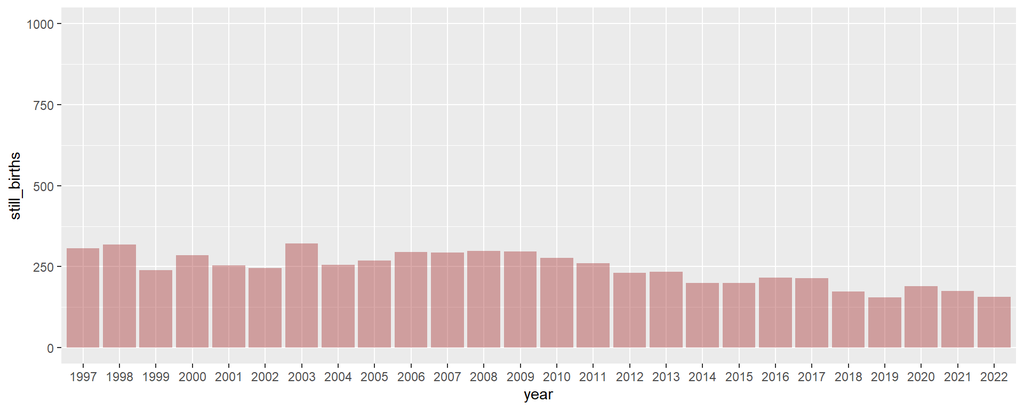

```r
ggplot(still_year, aes(year, still_births)) + geom_col(fill="brown", alpha=0.4) +
  ylim(0, 1000)
```

Live births at home. (Maybe not all home births were recorded in this dataset).

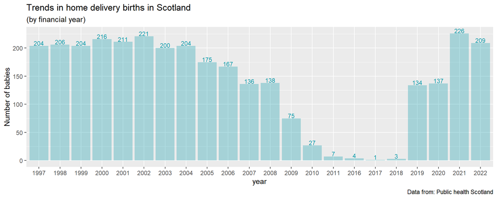

```r
home <- births %>%
  # D201N is the code for home births
  filter(hospital== "D201N") %>%
  group_by(year) %>%
  summarize(home_delivered = sum(smr02births))
ggplot(home, aes(year, home_delivered)) + geom_col(fill="#0097a7", alpha=0.3) +
   ylab("Number of babies") +
  geom_text(aes(label = home_delivered), vjust=-0.1, size =3, color='#0097a7') +
    labs(
    title = "Trends in home delivery births in Scotland",
    subtitle = "(by financial year)",
    caption="Data from: Public health Scotland")
```